# PyPI repository

The actual package can be found at https://pypi.org/project/ocpexplore/

# Github

The codes of the functions and a readme file can be found on github at https://github.com/martonberta/ocpexplore

# Possum dataset

The possum data frame consists of nine morphometric measurements on each of 104 **mountain brushtail possums**, trapped at seven sites from Southern Victoria to central Queensland.

[figure not shown]

# Load data and packages

```python
import pandas as pd
import numpy as np
```

```python
possums = pd.read_csv("https://vincentarelbundock.github.io/Rdatasets/csv/DAAG/possum.csv")
```

```python
# create a random date feature for the sake of the presentation
import random
possums['temp'] = [random.uniform(0,1) for i in range(possums.shape[0])]

possums.loc[possums.temp <= 0.2, 'date'] = pd.to_datetime("2019-06-01")
possums.loc[(possums.temp > 0.2) & (possums.temp <= 0.4) , 'date'] = pd.to_datetime("2019-07-01")
possums.loc[possums.temp >= 0.8, 'date'] = pd.to_datetime("2019-10-01")
possums.loc[(possums.temp >= 0.6) & (possums.temp < 0.8) , 'date'] = pd.to_datetime("2019-09-01")
possums.loc[possums.date.isnull(), 'date'] = pd.to_datetime("2019-08-01")

# rename cols
possums = possums.rename(columns={"case": "possum_id", "site":"site_id", "Pop":"region"})


# drop some features
todrop = ['temp', 'Unnamed: 0', 'hdlngth', 'skullw', 'taill', 'footlgth','earconch', 'eye']
possums = possums.drop(todrop, axis = 1)
```

```python
possums.head(10)
```

|  | possum_id | site_id | region | sex | age | totlngth | chest | belly | date |
| --- | --- | --- | --- | --- | --- | --- | --- | --- | --- |
| 0 | 1 | 1 | Vic | m | 8.0 | 89.0 | 28.0 | 36.0 | 2019-06-01 |
| 1 | 2 | 1 | Vic | f | 6.0 | 91.5 | 28.5 | 33.0 | 2019-09-01 |
| 2 | 3 | 1 | Vic | f | 6.0 | 95.5 | 30.0 | 34.0 | 2019-06-01 |
| 3 | 4 | 1 | Vic | f | 6.0 | 92.0 | 28.0 | 34.0 | 2019-06-01 |
| 4 | 5 | 1 | Vic | f | 2.0 | 85.5 | 28.5 | 33.0 | 2019-09-01 |
| 5 | 6 | 1 | Vic | f | 1.0 | 90.5 | 30.0 | 32.0 | 2019-09-01 |
| 6 | 7 | 1 | Vic | m | 2.0 | 89.5 | 30.0 | 34.5 | 2019-08-01 |
| 7 | 8 | 1 | Vic | f | 6.0 | 91.0 | 29.0 | 34.0 | 2019-07-01 |
| 8 | 9 | 1 | Vic | f | 9.0 | 91.5 | 28.0 | 33.0 | 2019-07-01 |
| 9 | 10 | 1 | Vic | f | 6.0 | 89.5 | 27.5 | 32.0 | 2019-08-01 |

# Functions of the ocpexplore package

The library can be loaded with the following code

```python
!pip install ocpexplore
import ocpexplore.ocpexplore as expl
```

```
You are using pip version 10.0.1, however version 20.0.2 is available.
```

### Missing values

From the chart it can be seen that only the age variable has missing values. This feature has 2 missing values, which is nearly 2 % of the total number of observations.

```
   variables  NANs  ratio
0  possum_id     0  0.000
1    site_id     0  0.000
2     region     0  0.000
3        sex     0  0.000
4        age     2  0.019
5   totlngth     0  0.000
6      chest     0  0.000
7      belly     0  0.000
8       date     0  0.000
```

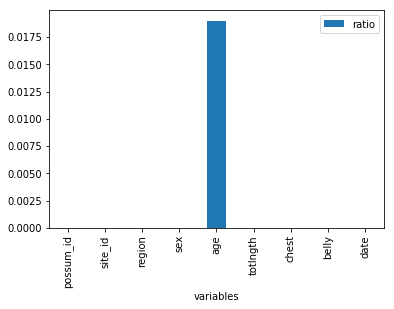

```python
expl.check_NA(possums)
```

### Keys in the data

The possum_id variable is unique in the data, while site_id is not (as expected), with 7 unique observations

```python
expl.check_ID(possums[['possum_id', 'site_id']])
```

```
possum_id has 104 values, and 104 of which are unique (100.0%).
site_id has 104 values, and 7 of which are unique (6.73%).
```

### Object variables

With the `value_counter` function we can check the distribution of object type variables if the number of unique observations is less than 25.

```
region
  unique_values  value_counts  ratio
0         other            58  0.558
1           Vic            46  0.442
```

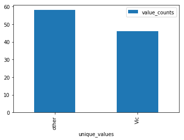

```
sex
  unique_values  value_counts  ratio
0             m            61  0.587
1             f            43  0.413
```

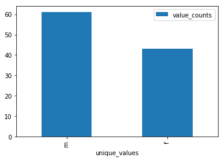

```
Unprocessed variables with object dtype: NA
```

```python
expl.value_counter(possums)
```

### Explore numeric variables

We can check the distribution of numeric variables visually and also with a descriptives table

```python
expl.describe_continuous(possums[['age','totlngth','chest','belly']])
```

|  | variable | Min | 0.01 | 0.05 | 0.1 | 0.25 | 0.5 | 0.75 | 0.9 | 0.95 | 0.99 | Max | Mean | NaN |
| --- | --- | --- | --- | --- | --- | --- | --- | --- | --- | --- | --- | --- | --- | --- |
| 0 | age | 1.0 | 1.0 | 1.0 | 2.0 | 2.0 | 3.0 | 5.0 | 6.0 | 7.0 | 9.0 | 9.0 | 3.833333 | 2 |
| 1 | totlngth | 75.0 | 76.0 | 80.5 | 81.5 | 84.0 | 88.0 | 90.0 | 92.0 | 93.5 | 96.0 | 96.5 | 87.088462 | 0 |
| 2 | chest | 22.0 | 23.0 | 23.5 | 24.5 | 25.5 | 27.0 | 28.0 | 30.0 | 30.5 | 31.0 | 32.0 | 27.000000 | 0 |
| 3 | belly | 25.0 | 27.0 | 28.0 | 29.0 | 31.0 | 32.5 | 34.0 | 36.0 | 36.5 | 39.0 | 40.0 | 32.586538 | 0 |

We drop (or impute) the rows with missing values, because the plot function does not handle missing values yet.

```python
possums = possums.dropna()
```

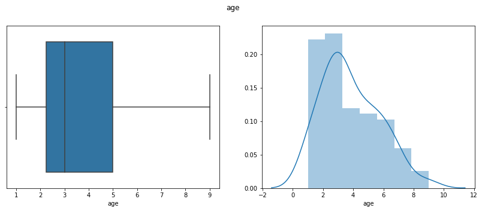

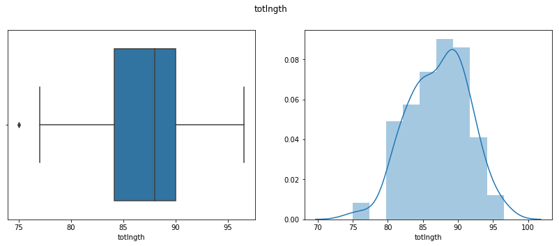

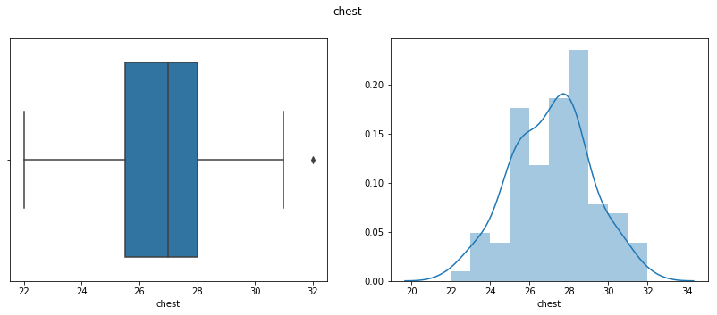

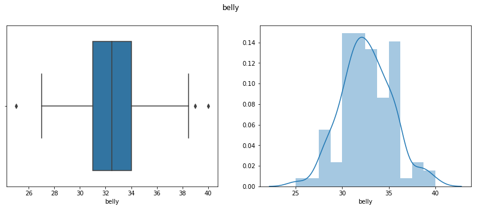

```python
expl.plot_continuous(possums[['age','totlngth','chest','belly']])
```

The boxplots showed some outliers, which we can check separately with the `tail_density_table`

```python
expl.tail_density_table(possums[['age','totlngth','chest','belly']])
```

| bucket | low_extreme | low_outlier | non_outlier | high_outlier | high_extreme |
| --- | --- | --- | --- | --- | --- |
| age | 0 | 0 | 102 | 0 | 0 |
| totlngth | 0 | 1 | 101 | 0 | 0 |
| chest | 0 | 0 | 101 | 1 | 0 |
| belly | 0 | 1 | 99 | 2 | 0 |

### Explore date variables

We can check if a day/month/year is missing from the data with the `obs_by_date` function. Contrary to the rest of the functions, this takes a single column as input.

```
2019-06    15
2019-07    24
2019-08    18
2019-09    26
2019-10    19
Freq: M, Name: date, dtype: int64
```

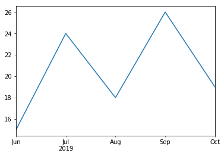

```python
expl.obs_by_date(possums.date, date_aggregation = 'M')
```

Also, we can check the distribution of numeric variables over time with the `values_by_date` function

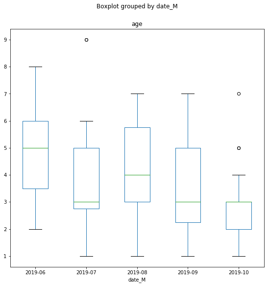

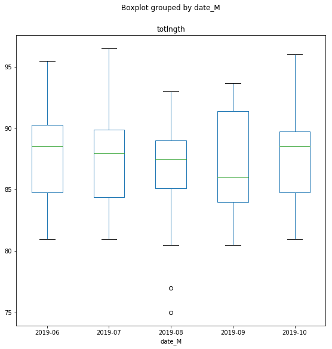

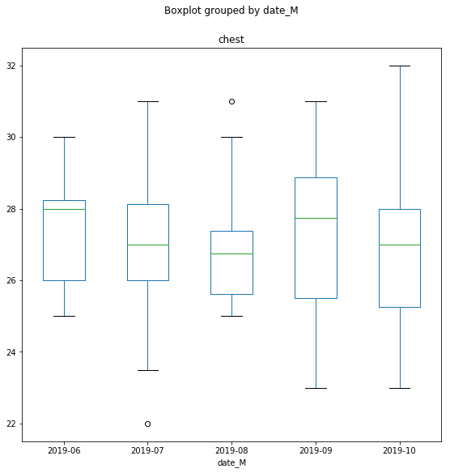

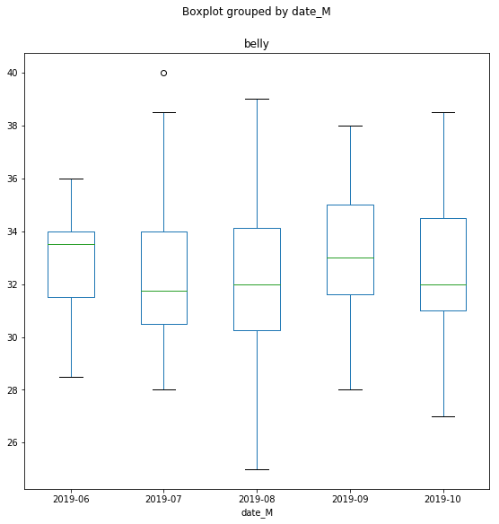

```python
expl.values_by_date(possums[['date','age','totlngth','chest','belly']], 'date')
```

# Lifecycle configuration

Doug created a process description, which makes it possible to have any package preinstalled upon opening a notebook instance in AWS. That can also be used to install this package.